# Your Digest for Wednesday, May 15, 2024 11:59 PM

[output not shown]

> **ST depression** and **T wave inversion** in leads corresponding to the right ventricle:
> - Right precordial leads V1-3 +/- V4
> - Inferior leads **II, III, aVF**, often **most pronounced in lead III** as this is the most rightward facing lead

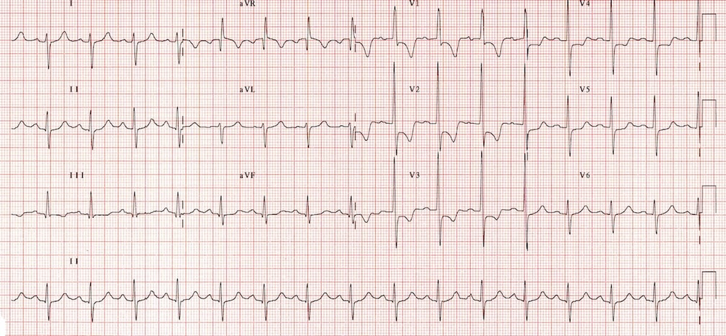

- Usually affects **bilateral lower lobes**.
- Permanent dilation -> ⭐*small airways are traceable almost upto the pleura*. (in normal lungs, they stop about *2 cm short of the pleura*)

> [!INFO]  
> Schober's test assesses the amount of lumbar flexion. In this test a mark is made at the level of the posterior iliac spine on the vertebral column, i.e. approximately at the level of L5. The examiner then places one finger 5cm below this mark and another finger at about 10cm above this mark.

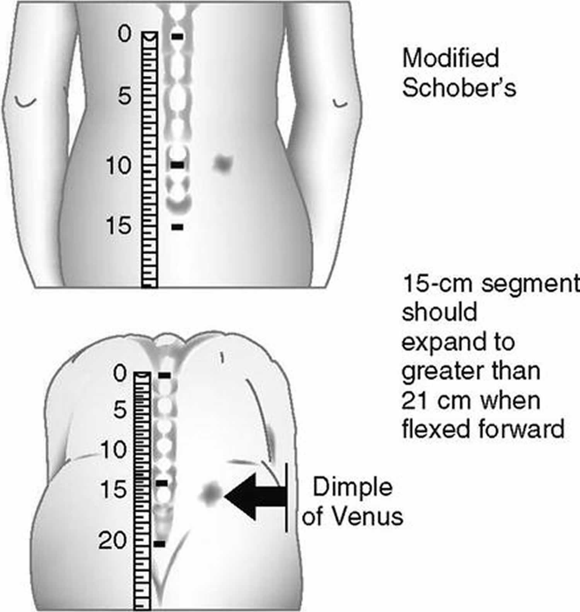

**Physical signs of Tamponade**

- Classic Beck triad of pericardial tamponade - Hypotension, muffled heart sounds, jugular venous distention
- Pulsus paradoxus - Exaggeration of physiologic respiratory variation in systemic blood pressure, defined as a decrease in systolic blood pressure of more than 10mm Hg with inspiration, signaling falling cardiac output during inspiration
- Pericardial friction rub
- Tachycardia
- Hepatojugular reflux - This can be observed by applying pressure to the periumbilical region; a rise in the jugular venous pressure (JVP) of greater than 3 cm H2 O for more than 30 seconds suggests elevated central venous pressure (however, transient elevation in JVP may be normal)